# Raport z analizy danych

Marcin Błaszyk

grudzień 11, 2015

# Wstęp - podsumowanie analizy.

Analizowany zbiór danych posiada bardzo wiele atrybutów (781) co znacząco utrudnia jego rzetelną analizę. Dodatkowo dla osoby niezaznajomionej z tematem protein i ligandów niektóre z kolumn danych wydają się dość abstrakcyjne. Zapewne analiza tego zbioru była by wielokrotnie łatwiejsza dla na przykład studenta biochemii.

Ze względu na ilość atrybutóW utrudniona była na przykład analiza korelacji. Dla czytelnego przedstawienia korelacji konieczny był podział na grupy kolumn. Dokonanie tego w odpowiedni sposób wymagało zapoznania się z charakterystyką danych.

Ilość klas w analizowanym zbiorze danych znaczaco utrudniała zbudowanie klasyfikatora. W celu uzyskania wyniku w sensownym czasie w warunkach domowych konieczne było mocne ograniczenie zbioru klas oraz używanie stosunkowo niskich wartości parametrów dla algorytmu tworzącego model. Niewątplie dostęp do potężniejszej maszyny bądź obsługa przetwarzania równoległego pomogłyby w tym aspekcie (Biblioteki pozwalające na równoległe przetwarzanie w R niestety nie występują dla nowszych wersji języka)

Mimo wpomnianych problemóW wykonywanie raportu niewątpliwie poszerzyło moją wiedzę na temat analizy i raportowania danych w R. Dodatkowo zachęciło mnie to nieco bliższego zapoznania się z projektem PDB - Protein Data Bank w późniejszym czasie.

# Przygotowanie do pracy

### Wykorzystane biblioteki

```r
library(dplyr)
library(tidyr)
library(knitr)
library(reshape2)
#rysowanie korelacji
library(corrplot)
#Do wykresów
library(ggplot2)
library(gridExtra)
library(RColorBrewer)
#uczenie maszynowe
library(caret)
```

### Zapewnienie powtarzalności wyników

Aby zapewnić powtarzalność wyników badań ustawiamy odpowiednio wartość początkową seed.

```r
set.seed(23)
```

# Wczytanie danych

Dokonujemy wczytania danych wejściowych. Plik z danymi musi mieć nazwę *all_summary.txt* i znajdować się w aktywnym working directory podczas generacji raportu. Warto zauważyć, że wbrew informacji w opisie zbioru danych wartości brakujące w kolumnach part_yy_xxx oznaczane są przez “nan” a nie “NA”. Zmiana wprowadzona została prawdopodobnie przez osobę przygotowującą zbiór danych ponieważ ciąg NA jest jednym z oznaczeń klas występujących w zbiorze.

```r
in_data <- tbl_df(
          read.csv("all_summary.txt",
                   sep = ';',
                   dec = '.',
                   na.strings = c("nan"," ","")))
```

# Ograniczenie zbioru danych

Ważną częścią pracy z danymi jest ograniczenie dostępnych danych do interesujących nas wartości. W tym przypadku stosujemy dwa kryteria ograniczenia przedstawione poniżej.

### Ograniczenie na podstawie wartości res_name

```r
filtered <- in_data%>% filter(!(res_name %in% c('DA','DC','DT','DU','DG','DI','UNK','UNX','UNL','PR','PD','Y1','EU','N','15P','UQ','PX4','NAN')))
```

### Unikatowe pary wartości pdb_code i res_name

Do celów analizy zachowujemy jedynie unikalne pary wartości pdb_code i res_name.

```r
dist_obs <- filtered %>% distinct(pdb_code,res_name)
```

# Krótkie podsumowanie

Oto tabela prezentująca krótkie podsumowanie wartości w każdej kolumnie.

```r
kable(summary(dist_obs))
```

|  | title | pdb_code | res_name | res_id | chain_id | local_BAa | local_NPa | local_Ra | local_RGa | local_SRGa | local_CCSa | local_CCPa | local_ZOa | local_ZDa | local_ZD_minus_a | local_ZD_plus_a | local_res_atom_count | local_res_atom_non_h_count | local_res_atom_non_h_occupancy_sum | local_res_atom_non_h_electron_sum | local_res_atom_non_h_electron_occupancy_sum | local_res_atom_C_count | local_res_atom_N_count | local_res_atom_O_count | local_res_atom_S_count | dict_atom_non_h_count | dict_atom_non_h_electron_sum | dict_atom_C_count | dict_atom_N_count | … |
| --- | --- | --- | --- | --- | --- | --- | --- | --- | --- | --- | --- | --- | --- | --- | --- | --- | --- | --- | --- | --- | --- | --- | --- | --- | --- | --- | --- | --- | --- | --- |
|  | 110l BME 901 A: 1 | 3ag4 : 16 | SO4 :1183 | 301 : 430 | A :8630 | Mode:logical | Mode:logical | Mode:logical | Mode:logical | Mode:logical | Mode:logical | Mode:logical | Mode:logical | Mode:logical | Mode:logical | Mode:logical | Min. : 1.00 | Min. : 1.00 | Min. : 0.00 | Min. : 3.0 | Min. : 0.00 | Min. : 0.000 | Min. : 0.00 | Min. : 0.000 | Min. :0.0000 | Min. : 1.00 | Min. : 3.0 | Min. : 0.00 | Min. : 0.000 | … |
|  | 111l CL 173 A : 1 | 3abl : 15 | ZN : 849 | 1 : 424 | B :2905 | NA’s:14132 | NA’s:14132 | NA’s:14132 | NA’s:14132 | NA’s:14132 | NA’s:14132 | NA’s:14132 | NA’s:14132 | NA’s:14132 | NA’s:14132 | NA’s:14132 | 1st Qu.: 1.00 | 1st Qu.: 1.00 | 1st Qu.: 1.00 | 1st Qu.: 30.0 | 1st Qu.: 30.00 | 1st Qu.: 0.000 | 1st Qu.: 0.00 | 1st Qu.: 0.000 | 1st Qu.:0.0000 | 1st Qu.: 1.00 | 1st Qu.: 30.0 | 1st Qu.: 0.00 | 1st Qu.: 0.000 | … |
|  | 115l BME 901 A: 1 | 3abk : 14 | GOL : 778 | 501 : 417 | C : 795 | NA | NA | NA | NA | NA | NA | NA | NA | NA | NA | NA | Median : 7.00 | Median : 7.00 | Median : 7.00 | Median : 55.0 | Median : 52.00 | Median : 3.000 | Median : 0.00 | Median : 3.000 | Median :0.0000 | Median : 7.00 | Median : 56.0 | Median : 3.00 | Median : 0.000 | … |
|  | 115l CL 173 A : 1 | 2afh : 11 | CA : 661 | 401 : 395 | D : 552 | NA | NA | NA | NA | NA | NA | NA | NA | NA | NA | NA | Mean : 13.59 | Mean : 13.43 | Mean : 13.05 | Mean :101.5 | Mean : 98.33 | Mean : 7.332 | Mean : 1.35 | Mean : 3.817 | Mean :0.2208 | Mean : 13.74 | Mean :103.8 | Mean : 7.47 | Mean : 1.357 | … |
|  | 123l BME 901 A: 1 | 3a0b : 11 | MG : 402 | 201 : 306 | E : 221 | NA | NA | NA | NA | NA | NA | NA | NA | NA | NA | NA | 3rd Qu.: 21.00 | 3rd Qu.: 20.00 | 3rd Qu.: 20.00 | 3rd Qu.:145.0 | 3rd Qu.:139.15 | 3rd Qu.:10.000 | 3rd Qu.: 2.00 | 3rd Qu.: 5.000 | 3rd Qu.:0.0000 | 3rd Qu.: 21.00 | 3rd Qu.:151.0 | 3rd Qu.:10.00 | 3rd Qu.: 2.000 | … |
|  | 123l CL 173 A : 1 | 3g6e : 11 | CL : 400 | 500 : 228 | H : 153 | NA | NA | NA | NA | NA | NA | NA | NA | NA | NA | NA | Max. :178.00 | Max. :104.00 | Max. :104.00 | Max. :800.0 | Max. :800.00 | Max. :81.000 | Max. :15.00 | Max. :55.000 | Max. :9.0000 | Max. :128.00 | Max. :866.0 | Max. :81.00 | Max. :20.000 | … |
|  | (Other) :14126 | (Other):14054 | (Other):9859 | (Other):11932 | (Other): 876 | NA | NA | NA | NA | NA | NA | NA | NA | NA | NA | NA | NA | NA | NA | NA | NA | NA | NA | NA | NA | NA’s :19 | NA’s :19 | NA’s :19 | NA’s :19 | … |

Po oczyszczeniu danych w zbiorze występuje 14132 obserwacji.

### Dodatkowe przygotowanie danych

Jak widać na powyższym podsumowaniu w danych znajduje się wiele pustych wartości. Podczas dalszej analizy konieczne może okazać się odpowiednie ich obsłużenie - przez podmianę na inne wartości bądź wykorzystanie udostępnionych przez metody parametrów wskazujących sposób obsługi wartości NA.

Dodatkowo w parę kolumn zawiera jedynie wartości NA. Nie wnoszą one absolutnie nic do dalszej analizy i można zarazem się ich pozbyć.

```r
dist_obs <- dist_obs  %>% select(-(local_BAa:local_ZD_plus_a),-(fo_col:weight_col))
```

# Sprawdzenie korelacji pomiędzy zmiennymi

W tej sekcji sprawdzimy korelację między zmiennymi zbioru danych. Ze względu na ilość kolumn w zbiorze danych (781) próba sprawdzenia korelacji dla każdej pary zmiennych była by nierozważna. bardzo trudno było by zinterpretować i przedstawić graficznie tak dużą macierz korelacji natomiast jej wyliczenie wymagało by dużych zasobów i charakteryzowało by się bardzo długim czasem trwania.

W zastępstwie wykorzystamy pewnie własności zbioru danych wynikające z jego opisu by przedstawić korelacje między niektórymi podzbiorami kolumn które powinny pokazać interesujace własności.

### Korelacja między kolumnami z wyłączeniem kolumn zaczynających się od “part”

Możemy zaobserwować korelację niektórych zmiennych. W następnej sekcji można zobaczyć dokładniejszy obraz korelacji między wartościami local i dict.

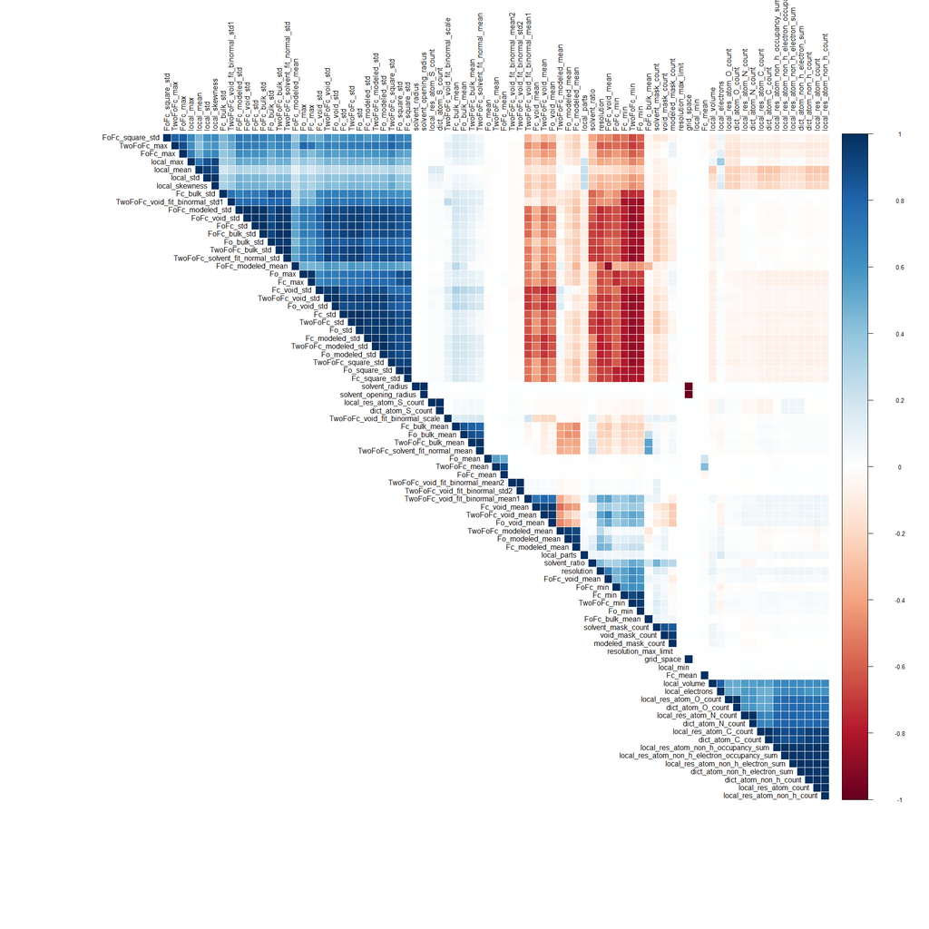

```r
#korelacja działa tylko na wartościach numerycznych

numeric_subset <- dist_obs %>% select(which(sapply(., is.numeric)))

#not parts
noPart <- numeric_subset %>% select(-starts_with("part"))
noPartCor <- cor(noPart,use="pairwise.complete.obs")
noPartCor[is.na(noPartCor)] <- 0
corrplot(noPartCor, method="color",type="upper",order="hclust",tl.col="black")
```

#### Korelacja między liczbami atomów i elektronów z pliku i wartościami teoretycznymi pochodzącymi z tablicy pierwiastków

Poniżej zobrazowano macierz korelacji dla kolumn local - opisujących liczby atomów i elektronów z pliku, oraz dict - opisujących te same wartości wyznaczone na podstawie danych słownikowych.

Jak widać szczególnie mocno skorelowane są wartości odpowiadających sobie kolumn lokalnych i słownikowych. Na uwagę wysoki stopień korelacji liczby atomów (local_res_atom_non_h_count) i liczby elektronów (local_res_atom_non_h_electron_sum). Ta obserwacja zostanie przywołana w następnej sekcji.

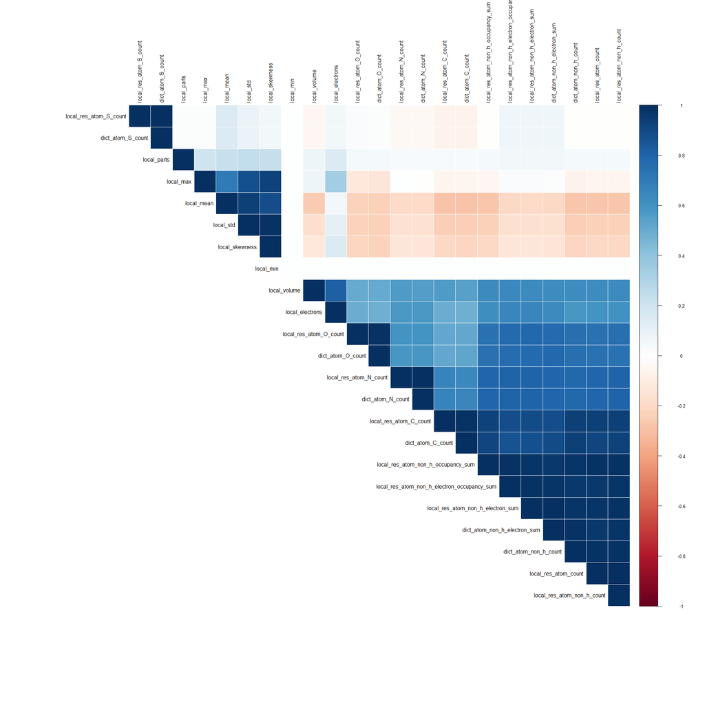

```r
#locals
local_dict<- dist_obs %>% select(starts_with("local"),starts_with("dict") )
local_dictCor <- cor(local_dict,use="pairwise.complete.obs")
local_dictCor[is.na(local_dictCor)] <-0
corrplot(local_dictCor, method="color",type="upper",order="hclust",tl.col="black")
```

### Korelacja między kolumnami dla odcięcia “part_01”

Na korelogramie można zobaczyc że mocno między sobą skorelowane są niezmienniki kształtu i gęstości (O3, O4, O5, FL,I1, I2, I3, I4, I5, I6). Również znormalizowane wartości niezmienników skorelowane są z wartościami przeskalowanymi. Nie są one jednak zbyt dobrze skorelowane z bezpośrednimi wartościami niezmienników.

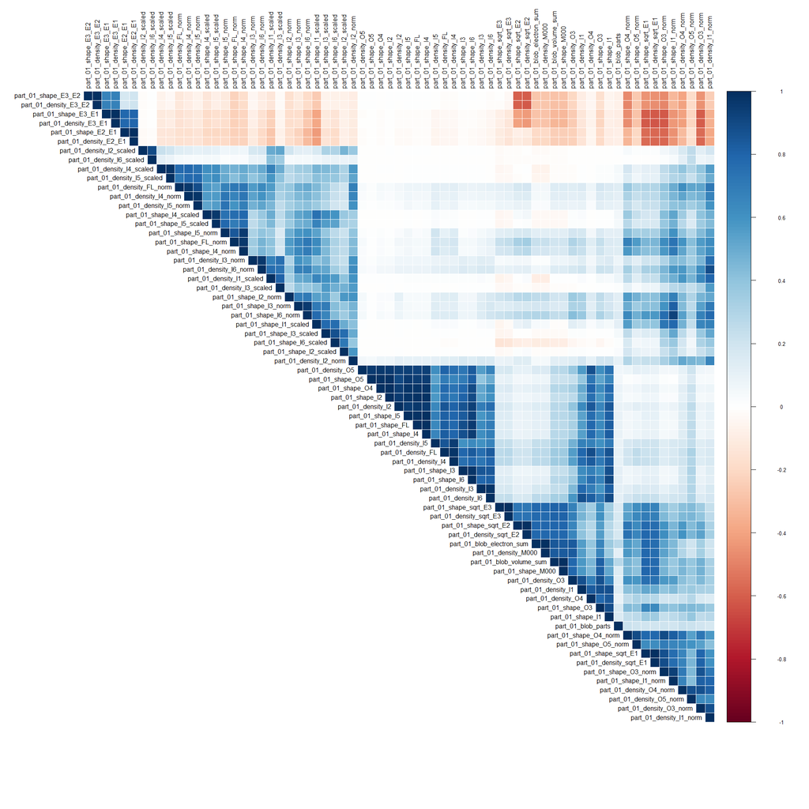

```r
#part01
p01 <- dist_obs %>% select(starts_with("part_01"))
p01Cor <- cor(p01,use="pairwise.complete.obs")
p01Cor[is.na(p01Cor)] <-0
corrplot(p01Cor, method="color",type="upper",order="hclust",tl.col="black")
```

### Korelacja między tymi samymi atrybutami dla różnych progów odcięć.

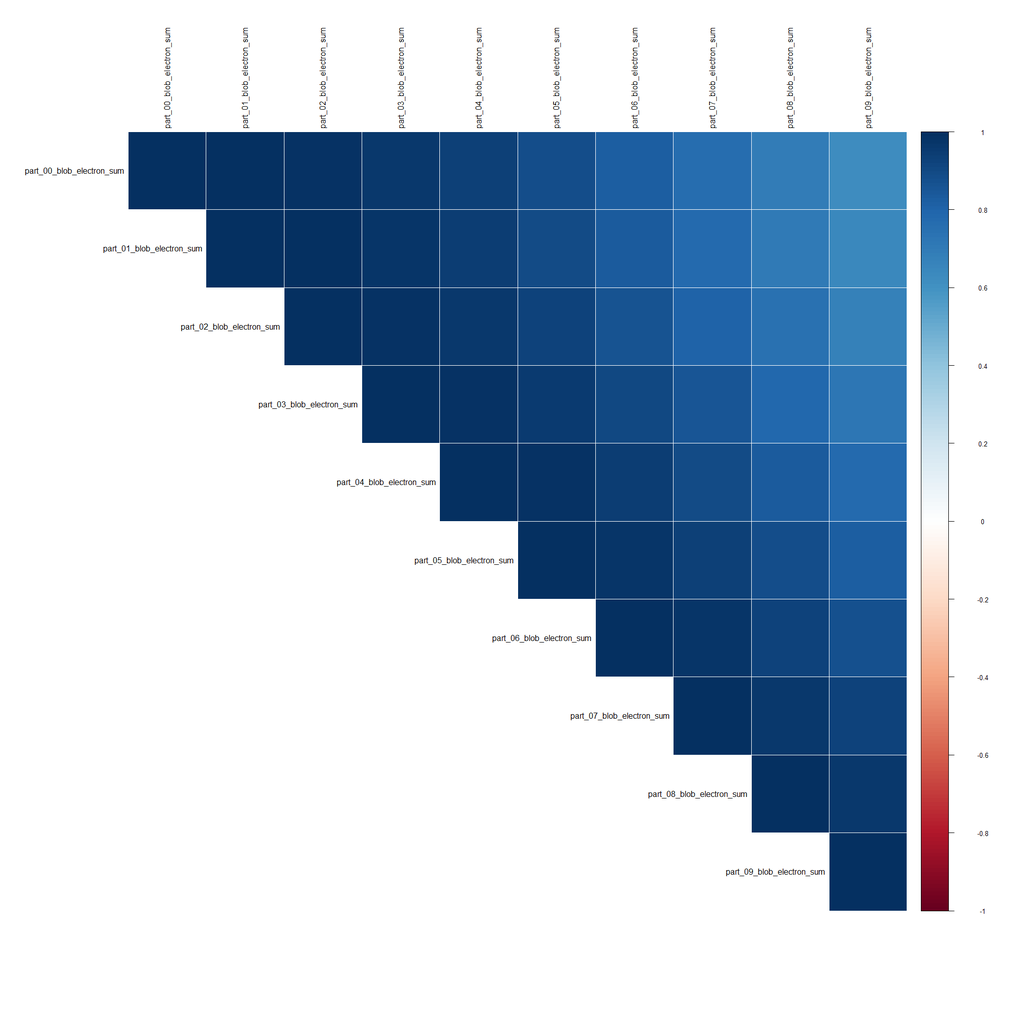

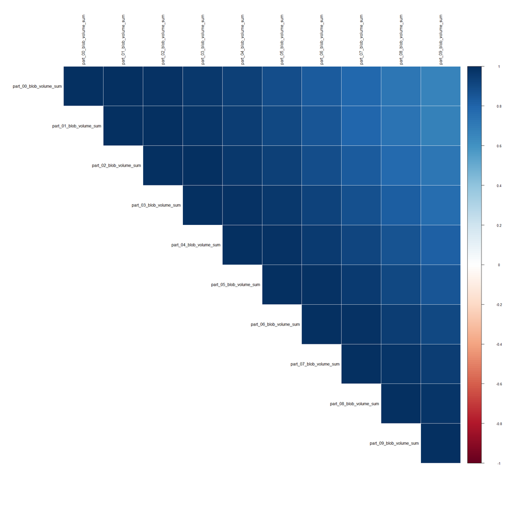

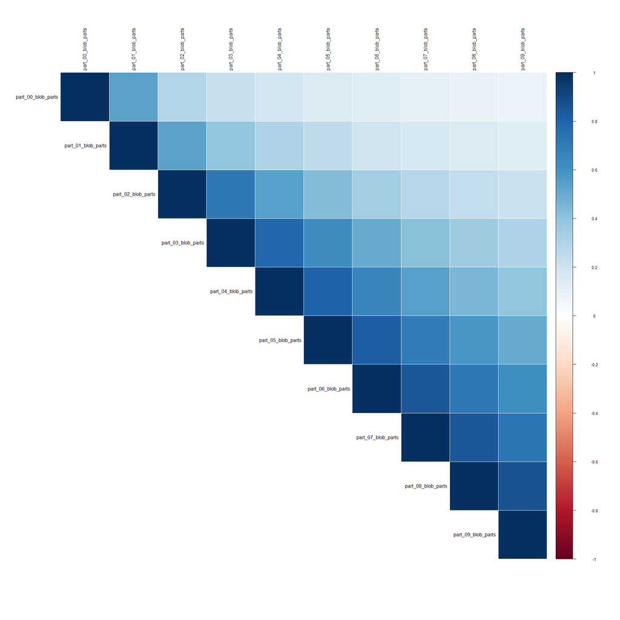

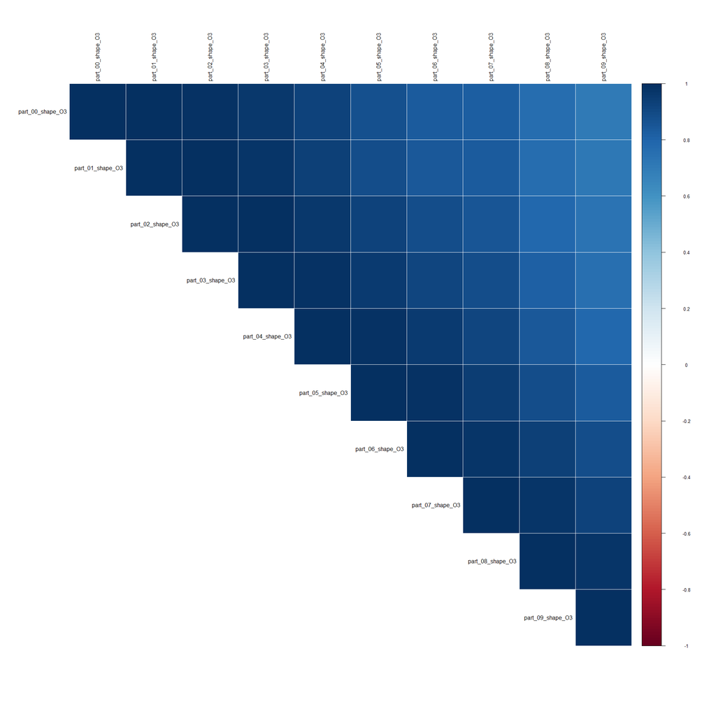

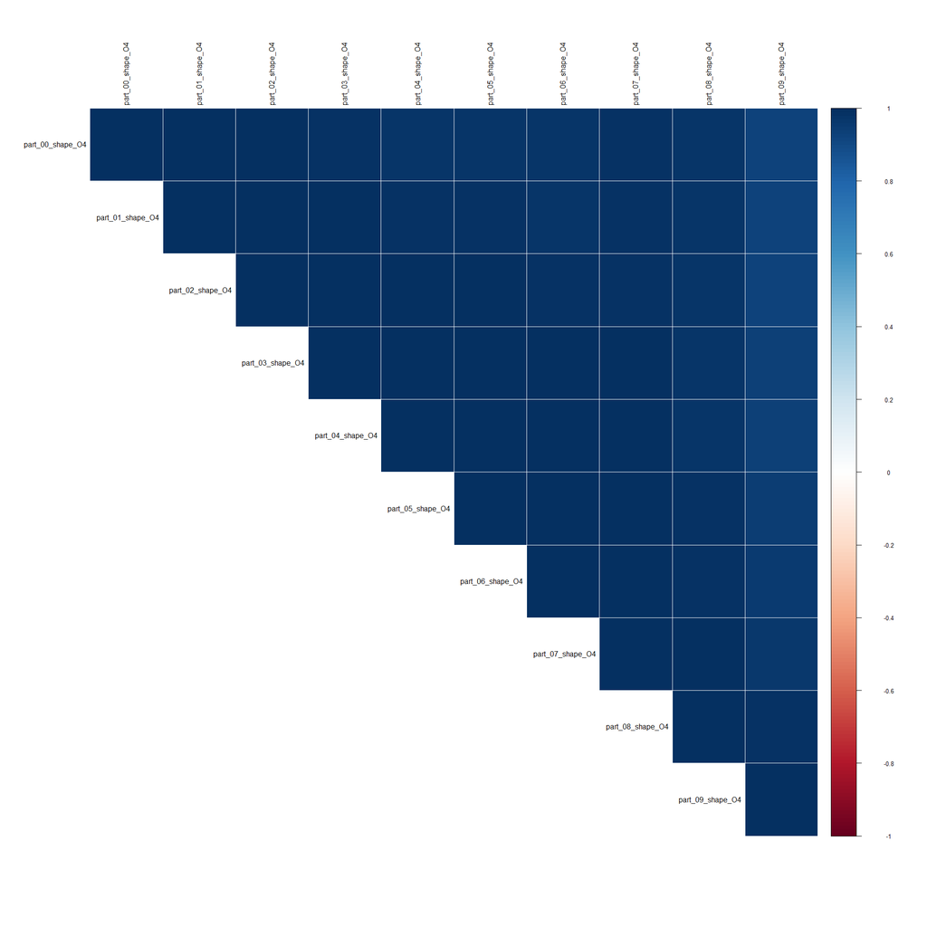

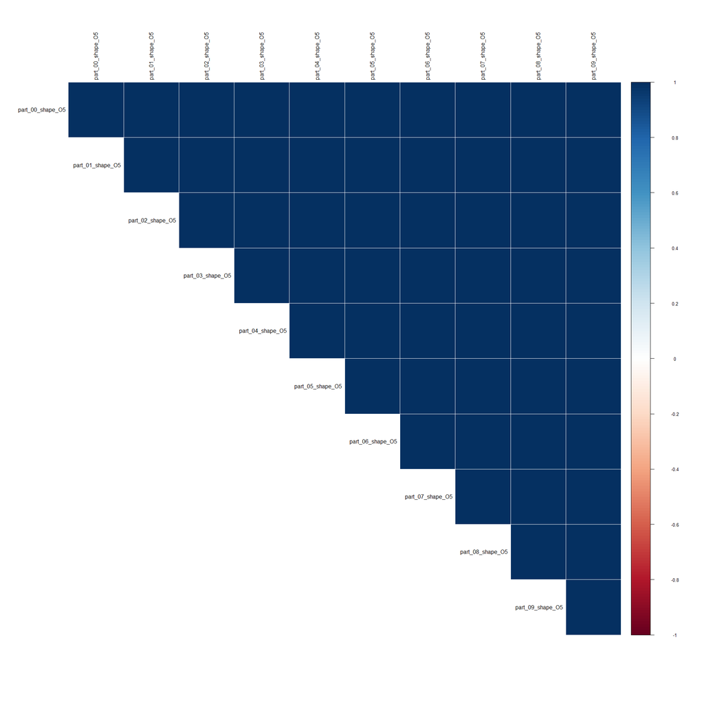

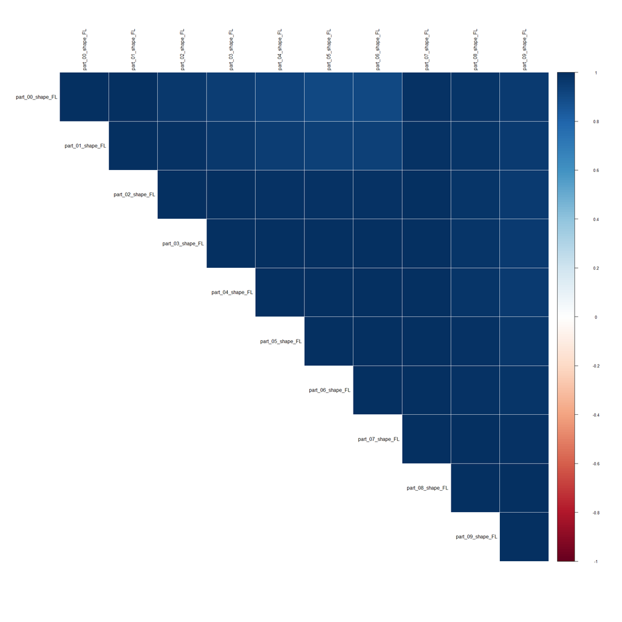

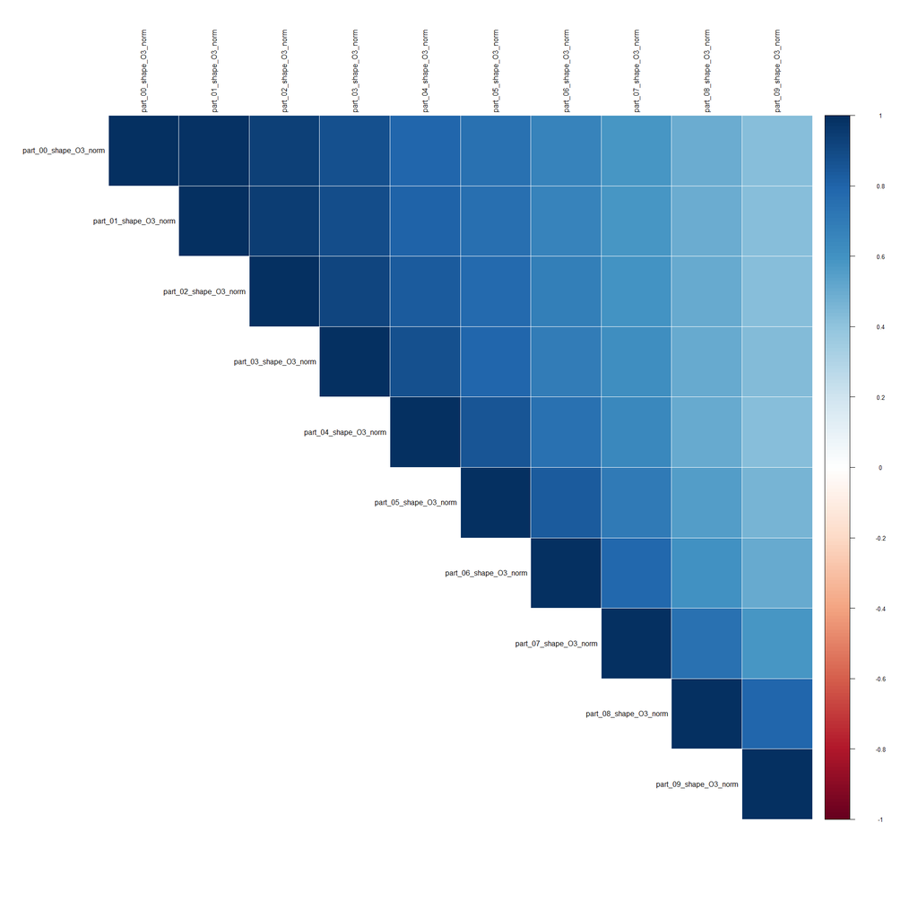

```r
#między partami
col_names_part<- substring(colnames(p01),9)
 for(iter in col_names_part[1:69:8]){
     x<- dist_obs %>% select(ends_with(iter))
     xCor <- cor(x,use="pairwise.complete.obs")
     xCor[is.na(xCor)]<-0
     corrplot(xCor, method="color",type="upper",order="alphabet",tl.col="black")
 }
```

# Ilość przykładów dla każdej z klas

W tej sekcji prezentujemy ilość przykładów jaką ma każda z klas.

```r
obs_per_class <- dist_obs   %>% count(res_name) %>% arrange(desc(n),res_name)
row.names(obs_per_class)<-obs_per_class$res_name
kable(t(obs_per_class%>%select(n)))
```

|  | SO4 | ZN | GOL | CA | MG | CL | NAG | PO4 | HEM | EDO | NA | MN | ACT | FAD | ADP | FE | K | ATP | CU | PEG | NAP | CD | NAD | MES | NI | FMN | EPE | BME | PG4 | … |
| --- | --- | --- | --- | --- | --- | --- | --- | --- | --- | --- | --- | --- | --- | --- | --- | --- | --- | --- | --- | --- | --- | --- | --- | --- | --- | --- | --- | --- | --- | --- |
| n | 1183 | 849 | 778 | 661 | 402 | 400 | 396 | 301 | 296 | 274 | 238 | 182 | 167 | 157 | 138 | 120 | 119 | 106 | 104 | 90 | 86 | 81 | 80 | 79 | 76 | 73 | 72 | 67 | 67 | … |

Jak łatwo zauważyć zbiór posiada kilka naprawdę licznych klas oraz wiele występujących w zbiorze jedynie kilkukrotnie. Wiedza ta może być pomocna w dalszej analizie do odpowiedniego ograniczania zbioru danych. Poniżej można zobaczyć poglądowo wykres słupkowy liczby wystąpień 25 najliczniejszych klas.

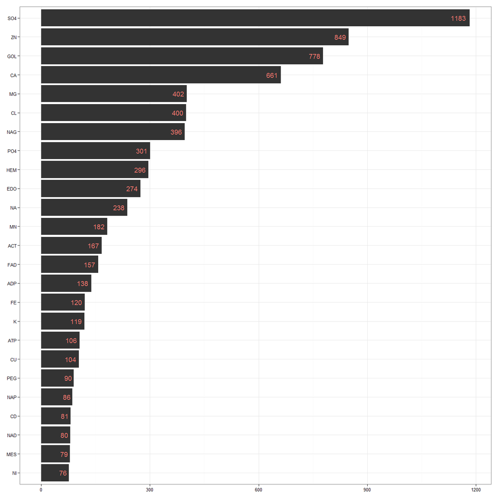

```r
ggplot(data = head(obs_per_class,25), aes(reorder(res_name,n),n)) + geom_bar(stat ="identity") + geom_text(aes(label=n,colour="blue"), vjust=0.5,hjust=1.25, show_guide = FALSE) + coord_flip()+theme_bw() + theme(axis.title=element_blank())
```

# Rozkład liczby atomów i elektronów

W poniższej części prezentujemy wykresy rozkładu liczby atomów i elektronów.

Na rozkładzie liczby atomów można zauważyć, że bardzo dużo ligandów zawiera raczej niewielką liczbę atomów. Powyżej 60 atomów w cząsteczce posiadają jedynie nieliczne cząsteczki. Można domyślić się że będą to ligandy z bardziej złożonych protein.

Rozkład liczby elektronów jest stosunkowo podobny kształtem do rozkładu atomów. Tej relacji można było spodziewać się jako, że w skład każdego atomu wchodzą elektrony a więc zmiana liczby atomów powinna wpływać na liczbę elektronów. Z tego właśnie wynika duży stopień skorelowania wartości dotyczących ilości atomów i ilości elektronów przedstawiony w poprzedniej sekcji.

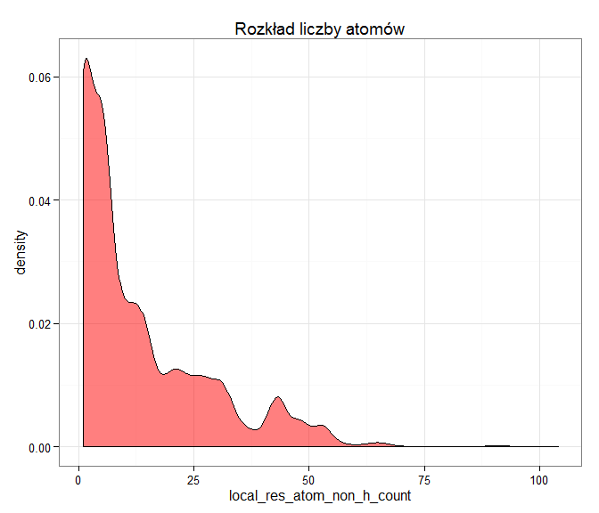

```r
#ograniczenie wartości do istotnych dla wykresów
for_plots <- dist_obs %>% select(local_res_atom_non_h_count,local_res_atom_non_h_electron_sum)


ggplot(for_plots,aes(x = local_res_atom_non_h_count)) + stat_density(colour="black", fill="red" ,alpha=0.5,rm.na=TRUE) + ggtitle("Rozkład liczby atomów") + theme_bw()
```

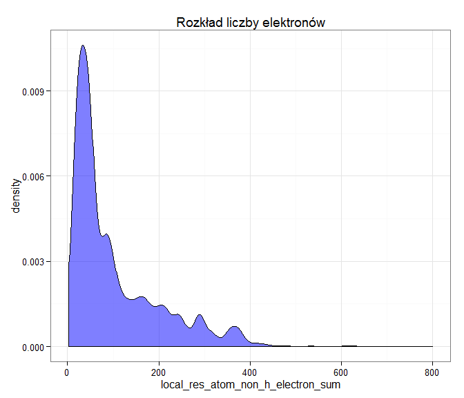

```r
ggplot(for_plots,aes(x = local_res_atom_non_h_electron_sum)) + stat_density(colour="black", fill="blue",alpha = 0.5 ,rm.na=TRUE) + ggtitle("Rozkład liczby elektronów") + theme_bw()
```

### Odwzorowanie wykresu

Dodatkowo na podstawie wzorca z zadania przygotowaliśmy ciekawy wykres prezentujący jednocześnie oba rozkłady. Widać na nim dokładnie powiązanie między rozkładami liczby atomów i elektronów.

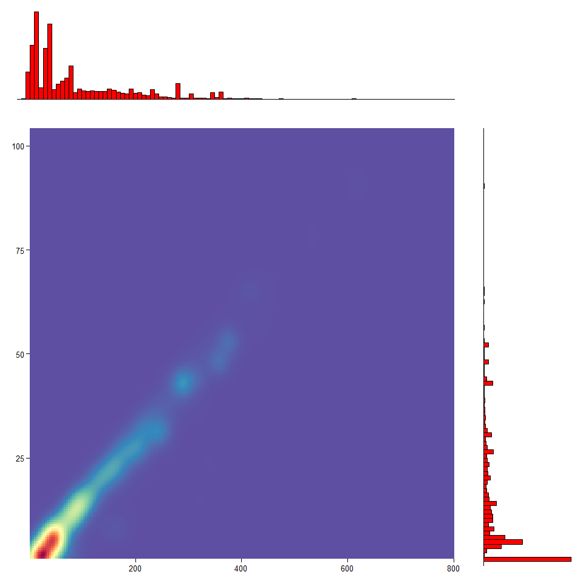

```r
empty <- ggplot()+geom_point(aes(1,1), colour="white") +
     theme(
       plot.background = element_blank(),
       panel.grid.major = element_blank(),
       panel.grid.minor = element_blank(),
       panel.border = element_blank(),
       panel.background = element_blank(),
       axis.title.x = element_blank(),
       axis.title.y = element_blank(),
       axis.text.x = element_blank(),
       axis.text.y = element_blank(),
       axis.ticks = element_blank()
     )

density_plot <- ggplot(for_plots,aes(x = local_res_atom_non_h_electron_sum, y = local_res_atom_non_h_count)) + stat_density2d(aes(fill = ..density..),contour = FALSE,geom = "tile", n = 200) +theme_classic()+ theme(legend.position = "none", axis.line=element_blank(),axis.title.x=element_blank(), axis.title.y=element_blank()) + scale_y_continuous(expand = c(0,0)) + scale_x_continuous(expand = c(0,0)) + scale_fill_gradientn(colours=rev(brewer.pal(11,"Spectral")))

#góra
plot_top <- ggplot(for_plots,aes(x = local_res_atom_non_h_electron_sum)) + stat_bin(binwidth = max(for_plots$local_res_atom_non_h_electron_sum)/100, colour="black", fill="red",rm.na=TRUE) +theme_classic()+ theme(legend.position = "none",axis.text.x=element_blank(),axis.text.y=element_blank(),axis.title.x=element_blank(), axis.title.y=element_blank(),axis.line.y=element_blank(),axis.ticks = element_blank()) + scale_y_continuous(expand = c(0,0)) + scale_x_continuous(expand = c(0,0))

#prawo
plot_side <- ggplot(for_plots,aes(x = local_res_atom_non_h_count))+ coord_flip() + stat_bin(binwidth = max(for_plots$local_res_atom_non_h_count)/100,  colour="black", fill="red",rm.na=TRUE) +theme_classic()+ theme(legend.position = "none",axis.text.x=element_blank(),axis.text.y=element_blank(),axis.title.x=element_blank(), axis.title.y=element_blank(), axis.line.x=element_blank(),axis.ticks = element_blank()) + scale_y_continuous(expand = c(0,0)) + scale_x_continuous(expand = c(0,0))

grid.arrange(plot_top, empty, density_plot, plot_side, ncol=2, nrow=2, widths=c(4, 1), heights=c(1, 4),padding = unit(0.1, "line"))
```

# Klasy charakteryzujace się największą niezgodnością liczby atomów i liczby elektronów

W poniższych tabelach przedstawiamy po 10 klas charakteryzujących się największą średnią niezgodnością liczby atomów i elektronów w stosunku do danych pochodzących z tablicy pierwiastków. Dla każdej klasy podane zostały wartości:

- licznosc.klasy
- wart.slownikowa - wartość słownikowa z którą porównujemy
- min.w.klasie - minimalna wartość z local
- max.w.klasie - maksymalna wartość z local
- srednia.niezgodnosc - średnia niezgodność liczby atomów lub elektronów dla danej klasy;
- wariancja.niezgodnosci - wariancja niezgodnosci liczby atomów lub elektronów dla danej klasy;
- min.niezgodnosc - minimalna niezgodność osiągnięta dla danej klasy;
- max.niezgodnosc - maksymalna niezgodność osiągnięta dla danej klasy.

```r
variance_atoms <- dist_obs %>%
  select(pdb_code,res_name,local_res_atom_non_h_count,dict_atom_non_h_count) %>%
  mutate(vari=abs(local_res_atom_non_h_count - dict_atom_non_h_count)) %>%
  group_by(res_name) %>%
  summarise(licznosc.klasy=n(),wart.slownikowa=first(dict_atom_non_h_count),min.w.klasie=min(local_res_atom_non_h_count),max.w.klasie=max(local_res_atom_non_h_count),srednia.niezgodnosc=mean(vari), wariancja.niezgodnosci=var(vari), min.niezgodnosc=min(vari), max.niezgodnosc=max(vari)) %>%
  arrange(desc(srednia.niezgodnosc))
kable(head(variance_atoms,10))
```

| res_name | licznosc.klasy | wart.slownikowa | min.w.klasie | max.w.klasie | srednia.niezgodnosc | wariancja.niezgodnosci | min.niezgodnosc | max.niezgodnosc |
| --- | --- | --- | --- | --- | --- | --- | --- | --- |
| PEU | 2 | 83 | 14 | 19 | 66.50000 | 12.5000 | 64 | 69 |
| PC1 | 3 | 54 | 11 | 39 | 33.33333 | 252.3333 | 15 | 43 |
| CPQ | 1 | 60 | 27 | 27 | 33.00000 | NA | 33 | 33 |
| JEF | 1 | 41 | 8 | 8 | 33.00000 | NA | 33 | 33 |
| VV7 | 1 | 128 | 95 | 95 | 33.00000 | NA | 33 | 33 |
| M0E | 1 | 109 | 77 | 77 | 32.00000 | NA | 32 | 32 |
| PTY | 2 | 50 | 19 | 19 | 31.00000 | 0.0000 | 31 | 31 |
| LI1 | 2 | 45 | 13 | 18 | 29.50000 | 12.5000 | 27 | 32 |
| IP9 | 1 | 51 | 24 | 24 | 27.00000 | NA | 27 | 27 |
| PEF | 1 | 47 | 20 | 20 | 27.00000 | NA | 27 | 27 |

```r
variance_electrons <- dist_obs %>%
  select(pdb_code,res_name,local_res_atom_non_h_electron_sum ,dict_atom_non_h_electron_sum) %>%
  mutate(vari=abs(local_res_atom_non_h_electron_sum - dict_atom_non_h_electron_sum)) %>%
  group_by(res_name) %>%
  summarise(licznosc.klasy=n(),wart.slownikowa=first(dict_atom_non_h_electron_sum),min.w.klasie=min(local_res_atom_non_h_electron_sum),max.w.klasie=max(local_res_atom_non_h_electron_sum),srednia.niezgodnosc=mean(vari), wariancja.niezgodnosci=var(vari), min.niezgodnosc=min(vari), max.niezgodnosc=max(vari)) %>%
  arrange(desc(srednia.niezgodnosc))

kable(head(variance_electrons,10))
```

| res_name | licznosc.klasy | wart.slownikowa | min.w.klasie | max.w.klasie | srednia.niezgodnosc | wariancja.niezgodnosci | min.niezgodnosc | max.niezgodnosc |
| --- | --- | --- | --- | --- | --- | --- | --- | --- |
| PEU | 2 | 554 | 94 | 128 | 443.0000 | 578.00 | 426 | 460 |
| CPQ | 1 | 393 | 168 | 168 | 225.0000 | NA | 225 | 225 |
| VV7 | 1 | 866 | 642 | 642 | 224.0000 | NA | 224 | 224 |
| JEF | 1 | 267 | 54 | 54 | 213.0000 | NA | 213 | 213 |
| PC1 | 3 | 350 | 66 | 259 | 211.6667 | 11064.33 | 91 | 284 |
| M0E | 1 | 736 | 540 | 540 | 196.0000 | NA | 196 | 196 |
| PEF | 1 | 308 | 120 | 120 | 188.0000 | NA | 188 | 188 |
| PTY | 2 | 326 | 140 | 140 | 186.0000 | 0.00 | 186 | 186 |
| IP9 | 1 | 386 | 201 | 201 | 185.0000 | NA | 185 | 185 |
| LI1 | 2 | 276 | 78 | 108 | 183.0000 | 450.00 | 168 | 198 |

# Rozkład wartości kolumn zaczynających się od part_01

W tej sekcji zobrazowano rozkłady wartości kolumn należących do pierwszego odcięcia.

Jak łatwo zauważyć dla wielu z kolumn wartości w zbiorze danych skupione są w okolicy zera za wyjątkiem pewnych nieraz daleko oddalonych ekstremów. Możliwe, że obecność takich ekstremów jest charakterystyczna dla określonych klas ligandów co mogło by wspomóc dalszą analizę i klasyfikację.

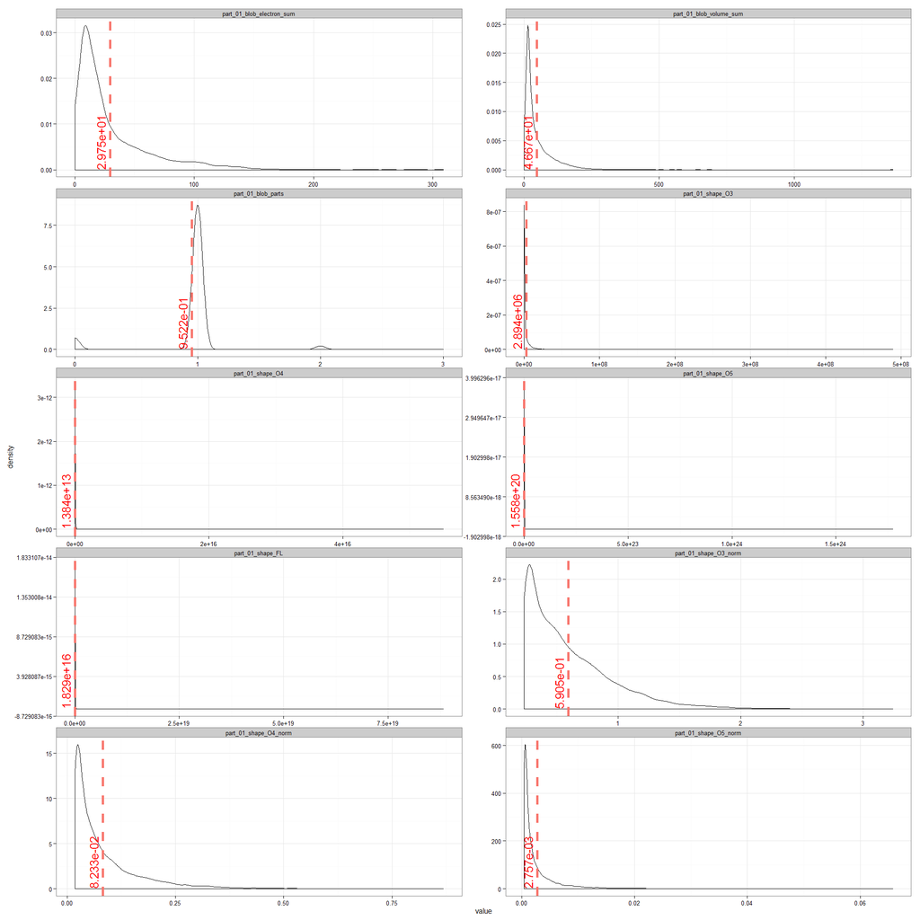

```r
fn <- function (data, x,y,ncol_plots) {
  cols_long <- data %>% select(x:y) %>% gather(column,value)
  means <- cols_long %>% group_by(column) %>% summarise(g.mean= mean(value,na.rm = TRUE))

  plot_part<- ggplot(cols_long)+geom_density(aes(x=value)) + facet_wrap(~ column ,ncol = ncol_plots, scales = "free")+
  geom_vline(data = means, aes(xintercept=g.mean, color="blue"), linetype="dashed",size=2) +
  geom_text(data=means, mapping=aes(x=g.mean, y=0, label=format(g.mean, digits=4)), size=7, angle=90, vjust=-0.5, hjust=0, color="red") +theme_bw()
  print(plot_part)
}

part01_cols <- dist_obs %>% select(contains("part_01"))
fn(part01_cols,1,10,2)
```

```r
fn(part01_cols,11,20,2)
```

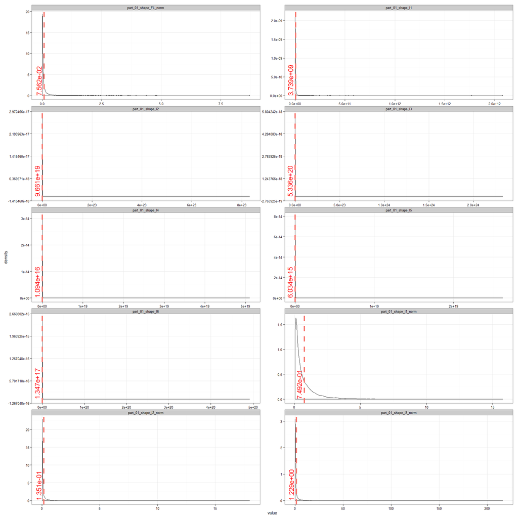

```r
fn(part01_cols,21,30,2)
```

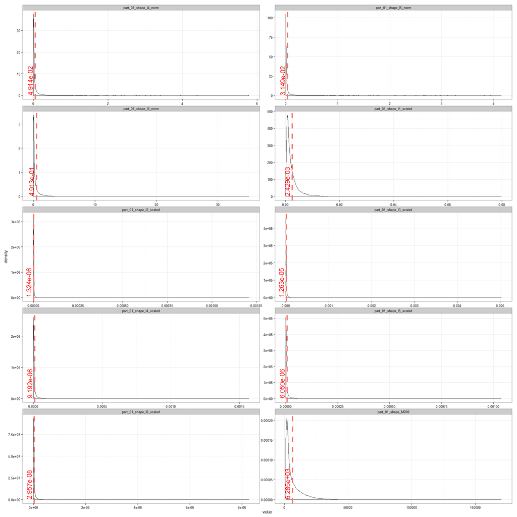

```r
fn(part01_cols,31,40,2)
```

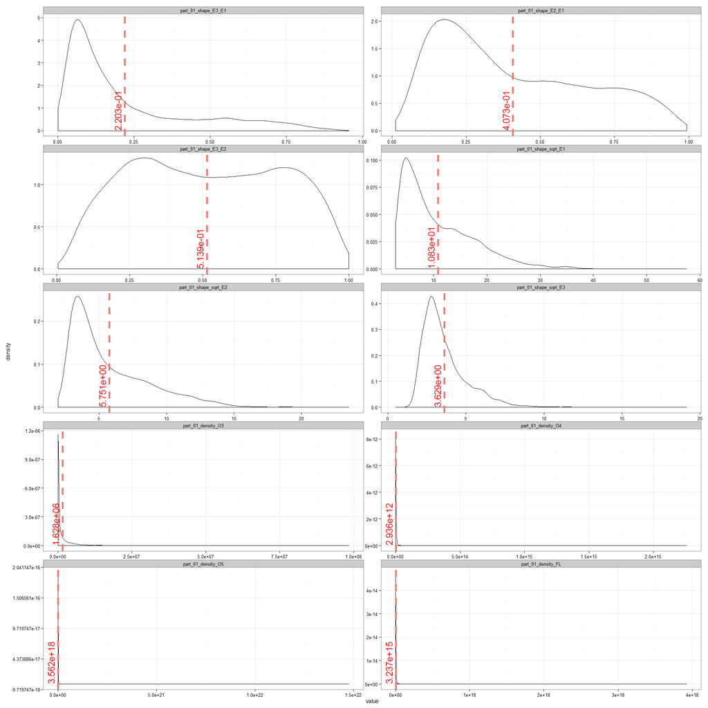

```r
fn(part01_cols,41,50,2)
```

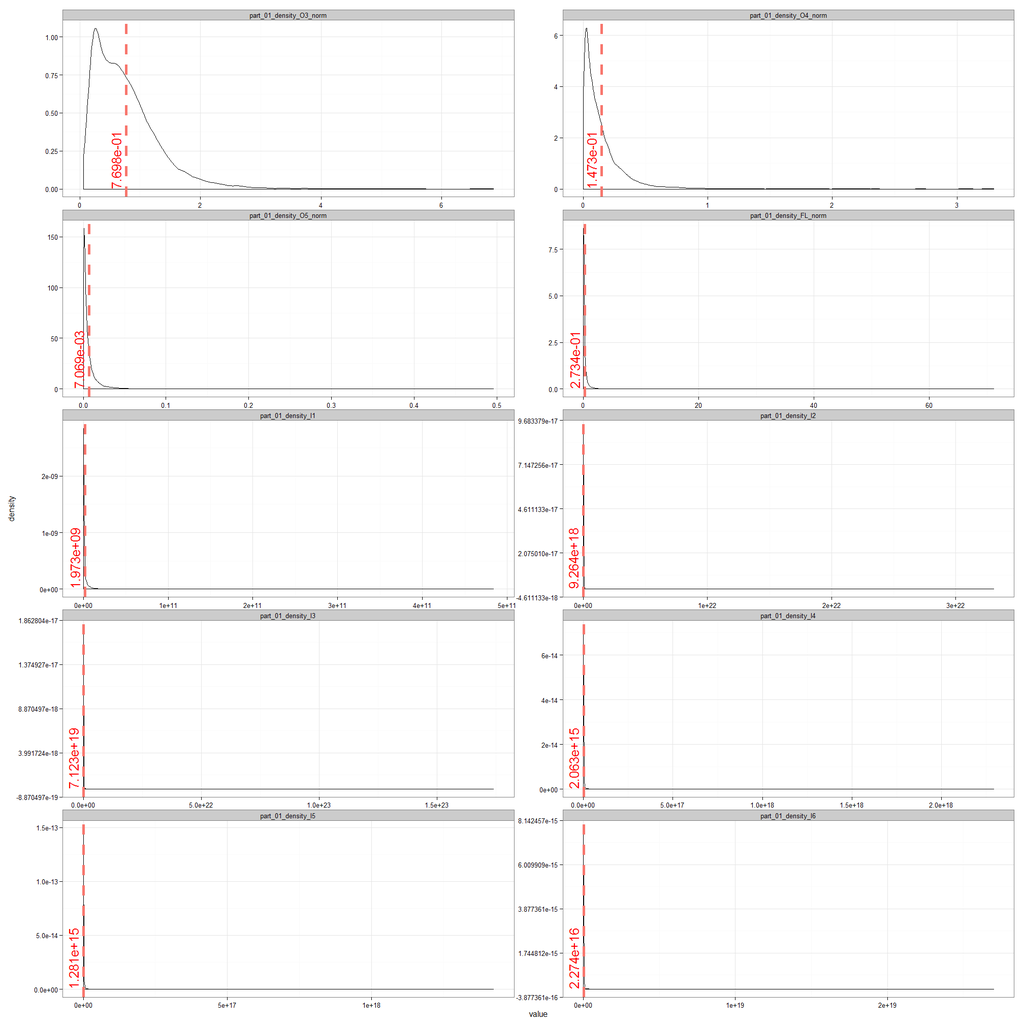

```r
fn(part01_cols,51,60,2)
```

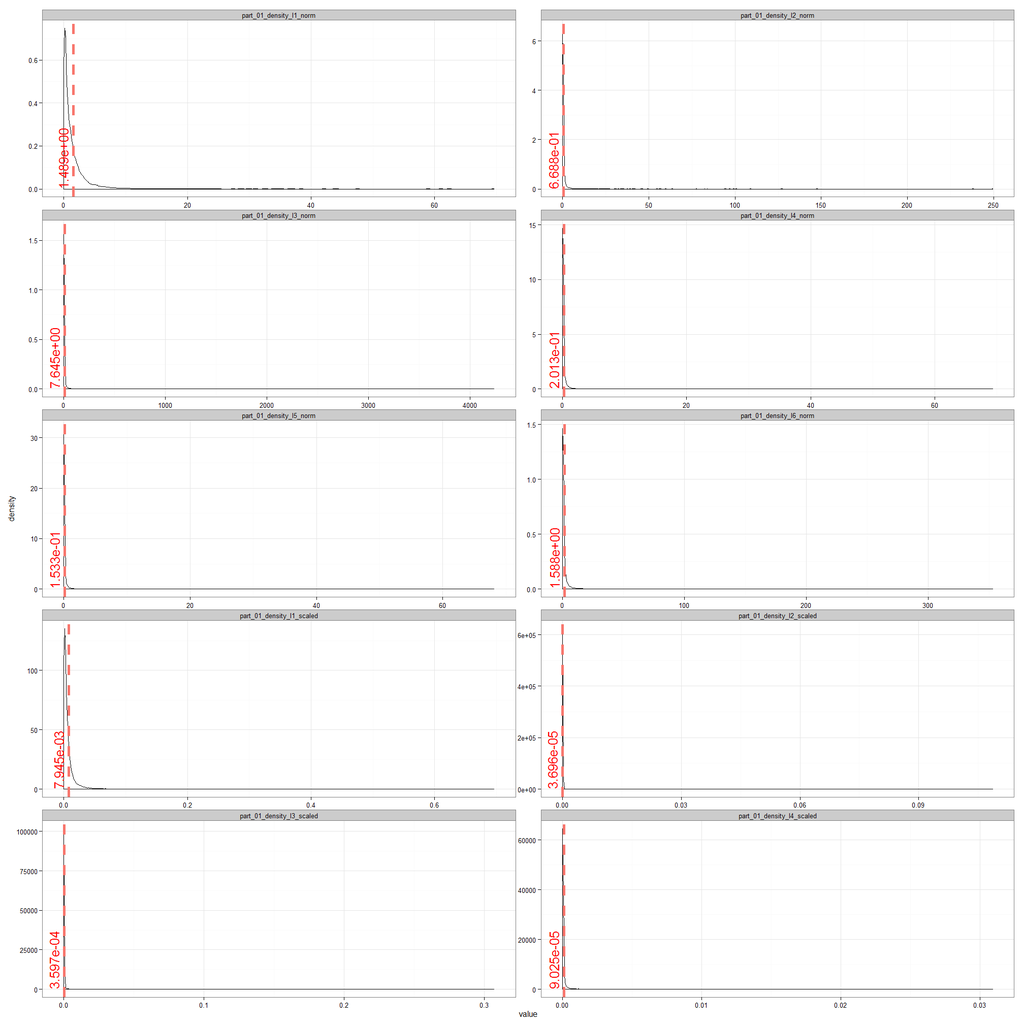

```r
fn(part01_cols,61,69,2)
```

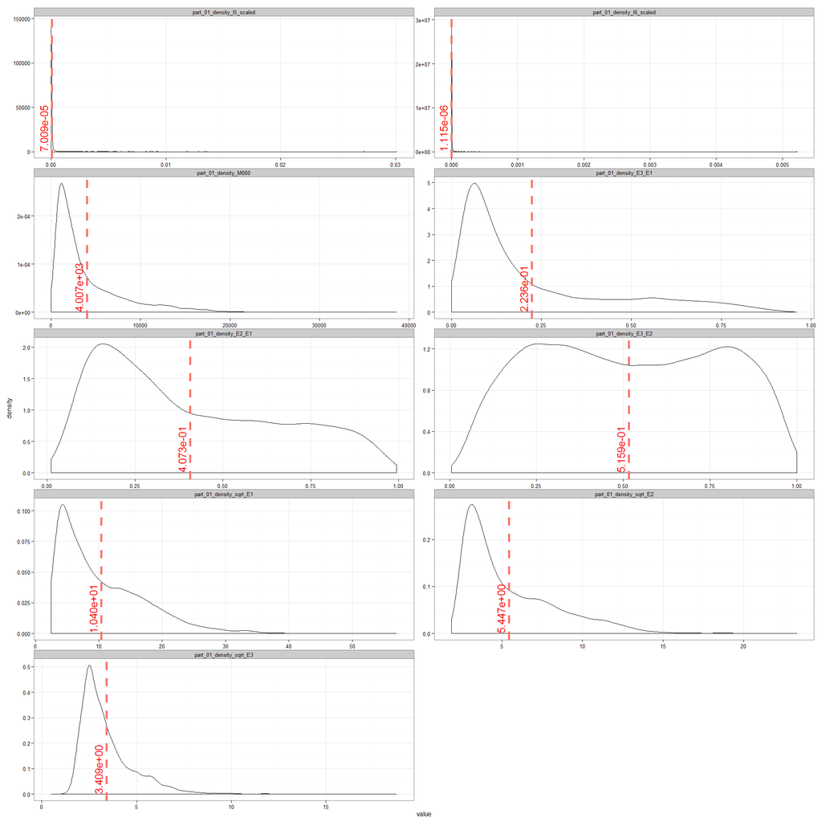

# Przewidywanie liczby atomów i liczby elektronów

W tej sekcji sprawdzimy czy możliwe jest przewidywanie liczby atomów i liczby elektronów w ligandzie na podstawie wartości z pozostałych kolumn. W tym celu utworzymy z pomocą biblioteki caret odpowiednie modele regresji liniowej.

### Przewidywanie liczby atomów na podstawie wartości z pozostałych kolumn

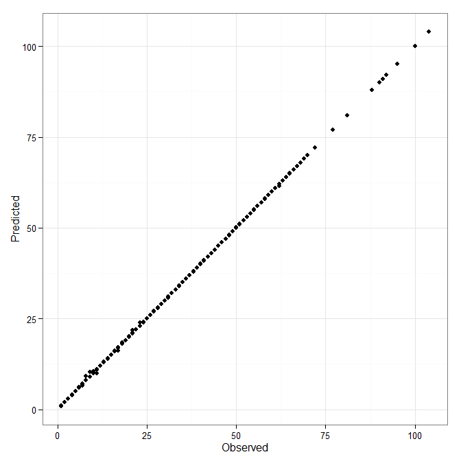

```r
#W celu pozbycia się wartości NA zamieniamy je tutaj na zero.
  dist_obs_NA0 <- dist_obs  %>% mutate_each(funs(replace(., which(is.na(.)), 0)),which( sapply(., is.numeric))
                                            )
  for_atom_pred <- dist_obs_NA0 %>% select(which( sapply(.,is.numeric)))
  ctrl<-trainControl(method = "cv",number = 10)

  test1 <- train(local_res_atom_non_h_count ~ .,
      data = for_atom_pred,
      method = "lm",
      trControl = ctrl)

  t1 <- predict(test1)
  outs <- data.frame(cbind(Predicted=t1,Observed=for_atom_pred$local_res_atom_non_h_count))
  ggplot(data = outs, aes(Observed,Predicted))+geom_point() +theme_bw()
```

```r
  kable(
    data.frame(
      R2=R2(t1,for_atom_pred$local_res_atom_non_h_count,na.rm = TRUE),
      RMSE=RMSE(t1,for_atom_pred$local_res_atom_non_h_count,na.rm = TRUE)
      )
    )
```

| R2 | RMSE |
| --- | --- |
| 0.9999965 | 0.0271075 |

Dodatkowo możemy dowiedzieć się interesujących rzeczy sprawdzając które kolumny były najważniejsze przy tworzeniu modelu regresji liniowej.

```r
  important<-varImp(test1)$importance
  kable(t(head(important[order(-important$Overall), , drop = FALSE],20)))
```

|  | dict_atom_non_h_count | local_res_atom_C_count | dict_atom_C_count | local_res_atom_O_count | dict_atom_O_count | dict_atom_non_h_electron_sum | local_res_atom_non_h_electron_sum | local_res_atom_N_count | dict_atom_N_count | local_res_atom_S_count | dict_atom_S_count | part_04_shape_O3_norm | part_04_blob_volume_sum | part_04_shape_O4_norm | part_04_density_I6_scaled | part_01_blob_parts | part_04_density_O3_norm | part_04_density_I4_norm | part_04_shape_O5_norm | part_04_density_O4_norm |
| --- | --- | --- | --- | --- | --- | --- | --- | --- | --- | --- | --- | --- | --- | --- | --- | --- | --- | --- | --- | --- |
| Overall | 100 | 39.52549 | 37.87405 | 22.93275 | 22.72335 | 22.41851 | 22.22226 | 18.37521 | 18.0866 | 1.111433 | 1.082412 | 0.4921634 | 0.4006569 | 0.3585734 | 0.3321957 | 0.3280771 | 0.3256414 | 0.3045423 | 0.2965194 | 0.2893217 |

Jak widać najważniejsza przy tworzeniu modelu była teoretyczna liczba atomów ustalona na podstawie tablicy pierwiastków. Następnie brane są pod uwagę inne wartości słownikowe oraz pozostałe lokalne ilości elektronów i atomów.

### Przewidywanie liczby elektronóW na podstawie wartości z pozostałych kolumn

Powtarzamy dla elektronów czynności wykonane wcześniej przy próbie przewidzenia liczby atomów.

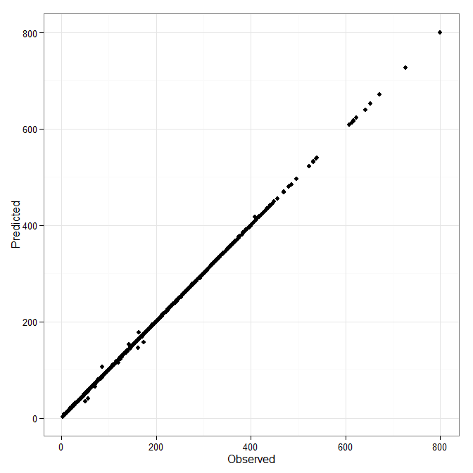

```r
  for_elec_pred <- dist_obs_NA0 %>% select(which( sapply(.,is.numeric)))
  ctrl<-trainControl(method = "cv",number = 10)

  test2 <- train(local_res_atom_non_h_electron_sum ~ .,
      data = for_elec_pred,
      method = "lm",
      trControl = ctrl)

  t2 <- predict(test2)
  outs <- data.frame(cbind(Predicted=t2,Observed=for_atom_pred$local_res_atom_non_h_electron_sum))
  ggplot(data = outs, aes(Observed,Predicted))+geom_point() +theme_bw()
```

```r
  kable(
    data.frame(
      R2=R2(t2,for_elec_pred$local_res_atom_non_h_electron_sum,na.rm = TRUE),
      RMSE=RMSE(t2,for_elec_pred$local_res_atom_non_h_electron_sum,na.rm = TRUE)
      )
    )
```

| R2 | RMSE |
| --- | --- |
| 0.9999805 | 0.4289393 |

```r
  important_elect<-varImp(test2)$importance
  kable(t(head(important_elect[order(-important_elect$Overall), , drop = FALSE],20)))
```

|  | dict_atom_non_h_electron_sum | local_res_atom_non_h_count | dict_atom_non_h_count | dict_atom_C_count | local_res_atom_C_count | dict_atom_O_count | local_res_atom_O_count | dict_atom_N_count | local_res_atom_N_count | local_res_atom_non_h_electron_occupancy_sum | local_res_atom_non_h_occupancy_sum | part_04_shape_O3_norm | part_04_blob_volume_sum | dict_atom_S_count | part_04_shape_O4_norm | local_res_atom_S_count | part_04_density_I6_scaled | part_04_density_O3_norm | part_05_density_E3_E2 | part_05_shape_E3_E2 |
| --- | --- | --- | --- | --- | --- | --- | --- | --- | --- | --- | --- | --- | --- | --- | --- | --- | --- | --- | --- | --- |
| Overall | 100 | 31.48571 | 30.28683 | 18.69065 | 18.5726 | 13.96722 | 13.85735 | 13.01739 | 12.99093 | 1.336545 | 1.328562 | 0.7687841 | 0.6206561 | 0.5860954 | 0.5795776 | 0.56044 | 0.5207798 | 0.5168197 | 0.5053254 | 0.4989273 |

# Klasyfikator wartości res_name

W tej sekcji spróbujemy zbudować klasyfikator przydzielający obserwacje do odpowiednich klas res_name. Wykorzystamy do tego podobnie jak w poprzednim przykładzie bibliotekę caret.

Ze względu na charakteryzującą język R konieczność trzymania wszystkich obiektów w pamięci oraz chęć uzyskania dokładniejszego klasyfikatora otrzymanych wyników ograniczymy odpowiednio zbiór klas które będziemy rozpatrywać.

Podczas wcześniejszej analizy sprawdzaliśmy ilość przykładów należących do każdej z klas. Wiele klas występowało wśród obserwacji jedynie jeden bądź kilka razy. Z tego powodu przyjmiemy pewien próg liczności występowania klas przekazanych do klasyfikacji.

W opisie danych oznaczone są kolumny które “prawdopodobnie nie będą dostępne podczas klasyfikacji”. Część z nich usunęliśmy już wcześniej uznając je za nie niosące żadnej dodatkowej informacji. Pozostałych pozbędziemy się teraz. Należą do nich między innymi kolumny dict i local które całkiem prawdopodobnie mocno ułatwiłyby klasyfikację.

Dodatkowo pozbędziemy się wartości NA w kolumnach liczbowych. Jako, że niektóre z kolumn danych posiada wartości bliskie zeru, w celu uniknięcia wprowadzania błędu klasyfikacji wartości NA zamienimy na duże wartości ujemne.

Uzyskany zbiór danych zostanie następnie stratyfikowany na zbiór treningowy i testowy. Na zbiorze treningowym zostanie zbudowany model algorytmu randomForest

```r
  top_res_names <- dist_obs   %>% count(res_name) %>% filter(n>100) %>% select(res_name)
  top_dist_obs <- dist_obs %>%
    filter(res_name %in% top_res_names$res_name) %>%
    select(-starts_with('dict_'),
           -starts_with('local_'),
           -c(title,pdb_code,res_id, chain_id,grid_space, solvent_radius, solvent_opening_radius, part_step_FoFc_std_min, part_step_FoFc_std_max, part_step_FoFc_std_step) )

  dist_obs_NAneg <- top_dist_obs  %>%
                    mutate_each(funs(replace(., which(is.na(.)), -999999)),which( sapply(., is.numeric)) )
  dist_obs_NAneg<- droplevels(dist_obs_NAneg)

  inTraining<-createDataPartition(y=dist_obs_NAneg$res_name,
                                  p=0.75,
                                  list=FALSE)

  training <- dist_obs_NAneg[ inTraining,]
  testing  <- dist_obs_NAneg[-inTraining,]

  ctrlClassify <- trainControl(
    method = "repeatedcv",
    number = 2,
    repeats = 5)

   rfGrid <- expand.grid(mtry = 10:30)
    fitTune <- train(res_name ~ .,
               data = training,
               method = "rf",
               trControl = ctrlClassify,
               tuneGrid = rfGrid,
               ntree = 25)
```

Po uzyskaniu modelu należy ocenić jego jakość. W tym przypadku zrobimy to wykorzystując macierz pomyłek oraz miary dla każdej z klas

```r
    predClasses <- predict(fitTune, newdata = testing)

  cm <- confusionMatrix(data = predClasses, testing$res_name)

  kable(cm$table)
```

|  | ACT | ADP | ATP | CA | CL | CU | EDO | FAD | FE | GOL | HEM | K | MG | MN | NA | NAG | PO4 | SO4 | ZN |
| --- | --- | --- | --- | --- | --- | --- | --- | --- | --- | --- | --- | --- | --- | --- | --- | --- | --- | --- | --- |
| ACT | 13 | 0 | 0 | 0 | 6 | 0 | 2 | 0 | 0 | 4 | 0 | 1 | 2 | 0 | 0 | 1 | 2 | 5 | 1 |
| ADP | 0 | 15 | 8 | 1 | 0 | 0 | 0 | 3 | 0 | 0 | 0 | 0 | 0 | 2 | 0 | 0 | 0 | 0 | 1 |
| ATP | 0 | 3 | 9 | 0 | 0 | 0 | 0 | 0 | 0 | 0 | 1 | 0 | 1 | 3 | 0 | 3 | 0 | 1 | 1 |
| CA | 0 | 1 | 3 | 83 | 7 | 3 | 0 | 0 | 3 | 1 | 2 | 3 | 10 | 5 | 5 | 0 | 3 | 8 | 10 |
| CL | 6 | 0 | 1 | 6 | 49 | 1 | 3 | 0 | 1 | 0 | 0 | 7 | 7 | 0 | 10 | 1 | 3 | 11 | 2 |
| CU | 0 | 0 | 0 | 0 | 0 | 4 | 0 | 0 | 0 | 0 | 0 | 0 | 0 | 0 | 0 | 0 | 0 | 0 | 0 |
| EDO | 0 | 0 | 0 | 1 | 3 | 0 | 19 | 0 | 0 | 6 | 0 | 1 | 2 | 0 | 3 | 0 | 0 | 2 | 0 |
| FAD | 0 | 2 | 0 | 1 | 0 | 0 | 0 | 28 | 0 | 0 | 1 | 0 | 0 | 1 | 0 | 1 | 0 | 0 | 0 |
| FE | 0 | 0 | 0 | 1 | 0 | 0 | 0 | 0 | 0 | 0 | 0 | 0 | 2 | 0 | 0 | 0 | 0 | 0 | 2 |
| GOL | 11 | 4 | 0 | 13 | 10 | 0 | 37 | 0 | 0 | 147 | 2 | 5 | 23 | 0 | 19 | 9 | 6 | 9 | 7 |
| HEM | 0 | 0 | 0 | 0 | 0 | 2 | 0 | 0 | 1 | 0 | 62 | 0 | 1 | 2 | 0 | 0 | 0 | 0 | 6 |
| K | 0 | 0 | 0 | 1 | 0 | 0 | 1 | 0 | 0 | 1 | 0 | 4 | 1 | 0 | 0 | 0 | 0 | 1 | 0 |
| MG | 1 | 1 | 0 | 10 | 0 | 0 | 1 | 0 | 0 | 7 | 1 | 2 | 24 | 0 | 4 | 2 | 1 | 4 | 2 |
| MN | 0 | 0 | 0 | 2 | 1 | 0 | 0 | 0 | 0 | 0 | 0 | 0 | 0 | 5 | 0 | 0 | 0 | 0 | 4 |
| NA | 0 | 0 | 0 | 0 | 2 | 0 | 1 | 0 | 1 | 3 | 1 | 0 | 4 | 1 | 7 | 0 | 1 | 3 | 3 |
| NAG | 0 | 4 | 5 | 6 | 1 | 1 | 1 | 7 | 0 | 10 | 2 | 1 | 7 | 4 | 4 | 81 | 1 | 5 | 3 |
| PO4 | 0 | 0 | 0 | 0 | 1 | 0 | 0 | 0 | 0 | 0 | 0 | 1 | 0 | 0 | 1 | 0 | 4 | 4 | 0 |
| SO4 | 9 | 0 | 0 | 21 | 20 | 0 | 3 | 0 | 4 | 15 | 2 | 4 | 10 | 4 | 5 | 0 | 50 | 241 | 3 |
| ZN | 1 | 4 | 0 | 19 | 0 | 15 | 0 | 1 | 20 | 0 | 0 | 0 | 6 | 18 | 1 | 1 | 4 | 1 | 167 |

```r
  kable(cm$byClass)
```

|  | Sensitivity | Specificity | Pos Pred Value | Neg Pred Value | Prevalence | Detection Rate | Detection Prevalence | Balanced Accuracy |
| --- | --- | --- | --- | --- | --- | --- | --- | --- |
| Class: ACT | 0.3170732 | 0.9856287 | 0.3513514 | 0.9832736 | 0.0239626 | 0.0075979 | 0.0216248 | 0.6513510 |
| Class: ADP | 0.4411765 | 0.9910555 | 0.5000000 | 0.9886972 | 0.0198714 | 0.0087668 | 0.0175336 | 0.7161160 |
| Class: ATP | 0.3461538 | 0.9922849 | 0.4090909 | 0.9899349 | 0.0151958 | 0.0052601 | 0.0128580 | 0.6692194 |
| Class: CA | 0.5030303 | 0.9586028 | 0.5646259 | 0.9475703 | 0.0964348 | 0.0485096 | 0.0859147 | 0.7308166 |
| Class: CL | 0.4900000 | 0.9633768 | 0.4537037 | 0.9681847 | 0.0584454 | 0.0286382 | 0.0631210 | 0.7266884 |
| Class: CU | 0.1538462 | 1.0000000 | 1.0000000 | 0.9871119 | 0.0151958 | 0.0023378 | 0.0023378 | 0.5769231 |
| Class: EDO | 0.2794118 | 0.9890444 | 0.5135135 | 0.9707288 | 0.0397428 | 0.0111046 | 0.0216248 | 0.6342281 |
| Class: FAD | 0.7179487 | 0.9964115 | 0.8235294 | 0.9934407 | 0.0227937 | 0.0163647 | 0.0198714 | 0.8571801 |
| Class: FE | 0.0000000 | 0.9970256 | 0.0000000 | 0.9824150 | 0.0175336 | 0.0000000 | 0.0029223 | 0.4985128 |
| Class: GOL | 0.7577320 | 0.8978247 | 0.4867550 | 0.9666430 | 0.1133840 | 0.0859147 | 0.1765050 | 0.8277783 |
| Class: HEM | 0.8378378 | 0.9926695 | 0.8378378 | 0.9926695 | 0.0432496 | 0.0362361 | 0.0432496 | 0.9152537 |
| Class: K | 0.1379310 | 0.9970273 | 0.4444444 | 0.9853114 | 0.0169492 | 0.0023378 | 0.0052601 | 0.5674792 |
| Class: MG | 0.2400000 | 0.9776536 | 0.4000000 | 0.9539673 | 0.0584454 | 0.0140269 | 0.0350672 | 0.6088268 |
| Class: MN | 0.1111111 | 0.9957983 | 0.4166667 | 0.9764567 | 0.0263004 | 0.0029223 | 0.0070134 | 0.5534547 |
| Class: NA | 0.1186441 | 0.9878935 | 0.2592593 | 0.9691211 | 0.0344828 | 0.0040912 | 0.0157802 | 0.5532688 |
| Class: NAG | 0.8181818 | 0.9615385 | 0.5664336 | 0.9885204 | 0.0578609 | 0.0473407 | 0.0835769 | 0.8898601 |
| Class: PO4 | 0.0533333 | 0.9957213 | 0.3636364 | 0.9582353 | 0.0438340 | 0.0023378 | 0.0064290 | 0.5245273 |
| Class: SO4 | 0.8169492 | 0.8940678 | 0.6163683 | 0.9590909 | 0.1724138 | 0.1408533 | 0.2285213 | 0.8555085 |
| Class: ZN | 0.7877358 | 0.9392929 | 0.6472868 | 0.9690296 | 0.1239041 | 0.0976037 | 0.1507890 | 0.8635144 |

Jak można zauważyć jakość klasyfikacji może pozostawiać wiele do życzenia. Dla wielu z klas pojawiają się spore błędy. Mając do dyspozycji lepsza maszynę można by generować model dla większego parametru ntree. Przeglądając dyskusje na temat klasyfikacji z użyciem algorytmu RandomForest znalazłem propozycje by dla kilkuset kolumn parametr ten sięgał kilku tysięcy.